# Simple Linear Regression Analysis

## 6.4 Model 2_3

```r
m2_3 <- lm(Price ~ KM_scaled + I(KM_scaled^2), data = train)
summary(m2_3)
```

```
##
## Call:
## lm(formula = Price ~ KM_scaled + I(KM_scaled^2), data = train)
##
## Residuals:
##     Min      1Q  Median      3Q     Max
## -6587.1 -1330.7  -318.2  1125.0  8505.4
##
## Coefficients:
##                Estimate Std. Error t value Pr(>|t|)
## (Intercept)     9710.00      76.01 127.748  < 2e-16 ***
## KM_scaled      -1444.35      78.61 -18.375  < 2e-16 ***
## I(KM_scaled^2)   217.45      39.24   5.541 3.92e-08 ***
## ---
## Signif. codes:  0 '***' 0.001 '**' 0.01 '*' 0.05 '.' 0.1 ' ' 1
##
## Residual standard error: 1983 on 924 degrees of freedom
## Multiple R-squared:  0.2861, Adjusted R-squared:  0.2846
## F-statistic: 185.1 on 2 and 924 DF,  p-value: < 2.2e-16
```

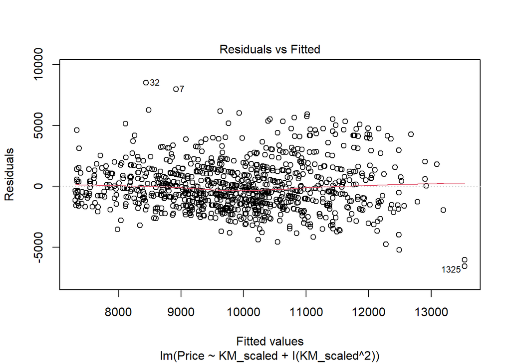

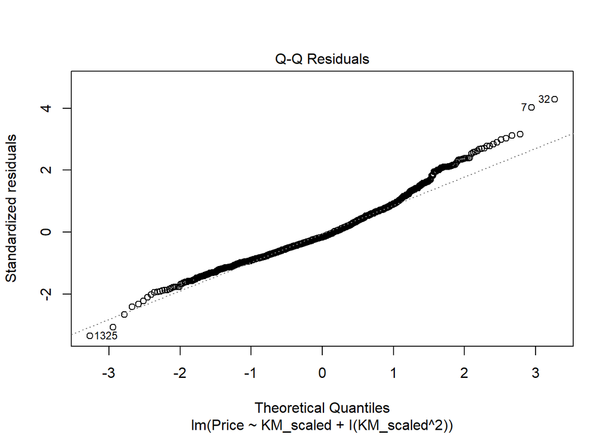

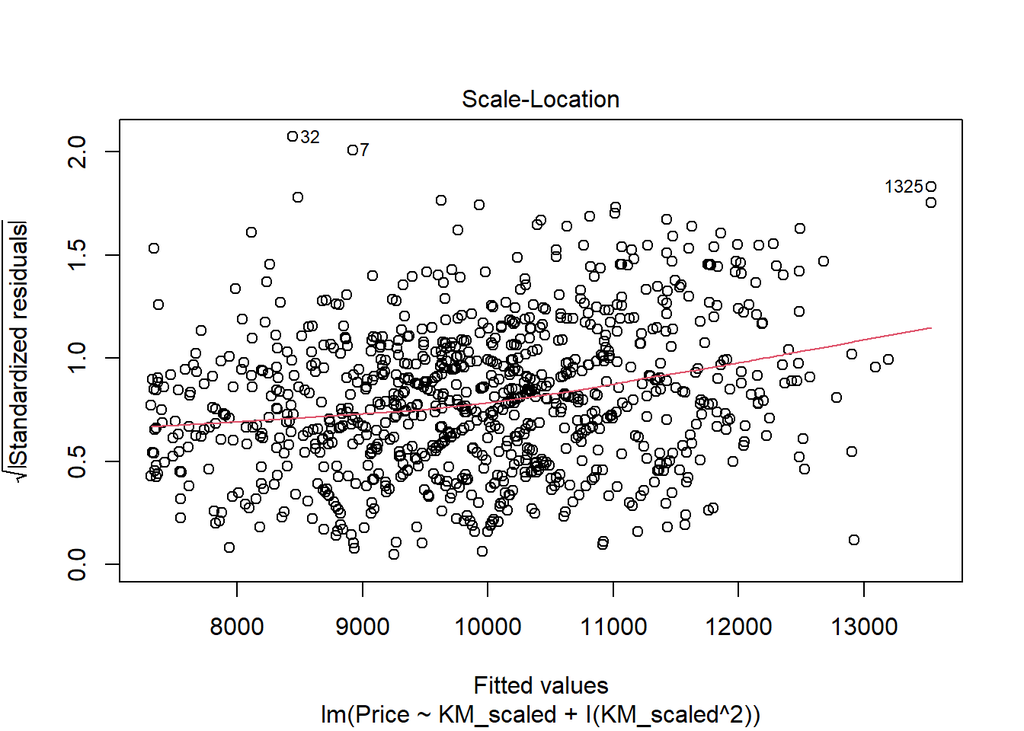

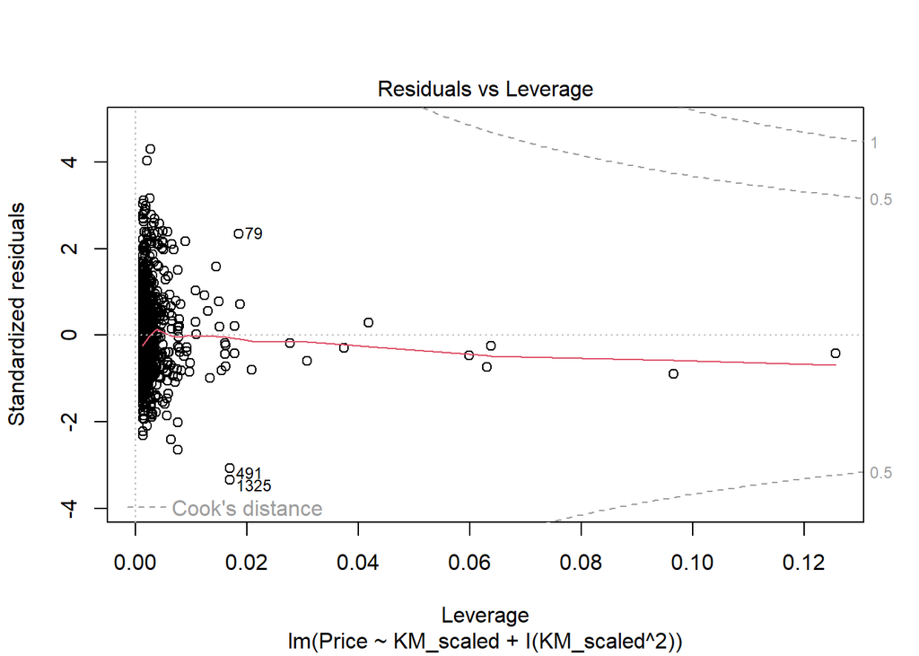

```r
plot(m2_3)
```

```r
car::vif(m2_3)
```

```
##      KM_scaled I(KM_scaled^2)
##       1.455471       1.455471
```

- Model m2 pluralization:
  - consider KM and KM<sup>2</sup> (are important variables to explain ‘Price’: explain 30% variance of ‘Price’)
  - improve R<sup>2</sup>
  - solve Heteroscedasticity problem
  - Regression Normality Assumption violation did not solve -> maybe is just because some outliers (if be true, we can remove them and solve this problem)
  - we use KM_scaled and KM_scaled<sup>2</sup> to prevent Multicollinearity problem

## 6.5 Model 3: we want to bring all variables of dataset to model

```r
summary(train[,c(4,6,7,9)])
```

```
##    FuelType   MetColor Automatic Doors
##  CNG   : 13   0:314    0:876     2:  1
##  Diesel: 94   1:613    1: 51     3:431
##  Petrol:820                      4: 88
##                                  5:407
```

```r
train$FuelType <- factor(train$FuelType, levels = c("Petrol", "Diesel", "CNG"))
train$MetColor <- factor(train$MetColor, levels = c("1", "0"))
train$Automatic <- factor(train$Automatic, levels = c("0", "1"))
train$Doors <- factor(train$Doors, levels = c("3", "5", "4", "2"))

m3 <- lm(Price ~ KM_scaled + I(KM_scaled^2) + Age + FuelType + HP + MetColor + Automatic + CC + Doors + Weight, data = train)
summary(m3)
```

```
##
## Call:
## lm(formula = Price ~ KM_scaled + I(KM_scaled^2) + Age + FuelType +
##     HP + MetColor + Automatic + CC + Doors + Weight, data = train)
##
## Residuals:
##     Min      1Q  Median      3Q     Max
## -4911.5  -658.6    -5.5   676.2  3892.8
##
## Coefficients:
##                 Estimate Std. Error t value Pr(>|t|)
## (Intercept)     6202.235   1293.928   4.793 1.91e-06 ***
## KM_scaled       -419.465     53.314  -7.868 1.02e-14 ***
## I(KM_scaled^2)   -48.823     23.149  -2.109   0.0352 *
## Age             -114.661      2.959 -38.752  < 2e-16 ***
## FuelTypeDiesel -2205.388    942.666  -2.340   0.0195 *
## FuelTypeCNG     -599.835    312.974  -1.917   0.0556 .
## HP               -17.074     14.398  -1.186   0.2360
## MetColor0          5.497     76.255   0.072   0.9425
## Automatic1       442.610    161.966   2.733   0.0064 **
## CC                 2.392      1.132   2.113   0.0349 *
## Doors5           192.826     81.015   2.380   0.0175 *
## Doors4           112.917    130.216   0.867   0.3861
## Doors2          -314.473   1084.321  -0.290   0.7719
## Weight             8.135      1.271   6.401 2.47e-10 ***
## ---
## Signif. codes:  0 '***' 0.001 '**' 0.01 '*' 0.05 '.' 0.1 ' ' 1
##
## Residual standard error: 1081 on 913 degrees of freedom
## Multiple R-squared:  0.7904, Adjusted R-squared:  0.7875
## F-statistic: 264.9 on 13 and 913 DF,  p-value: < 2.2e-16
```

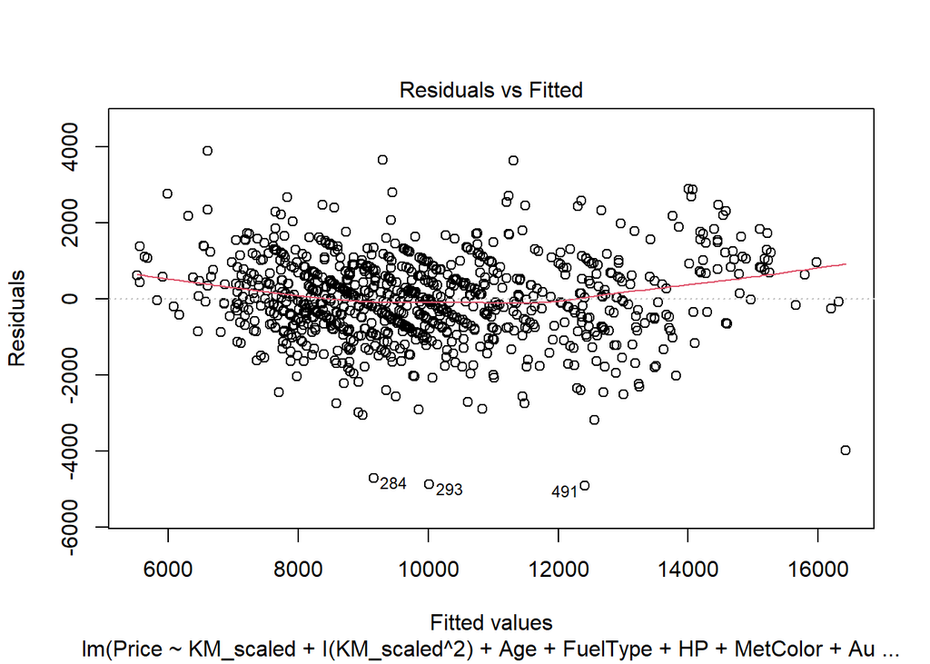

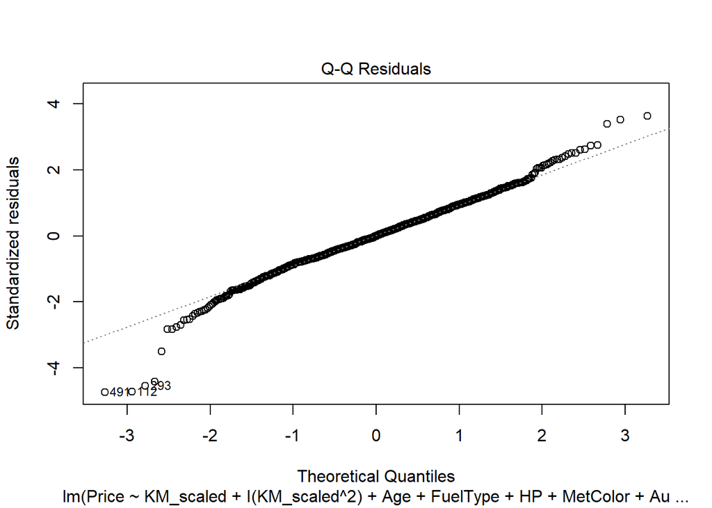

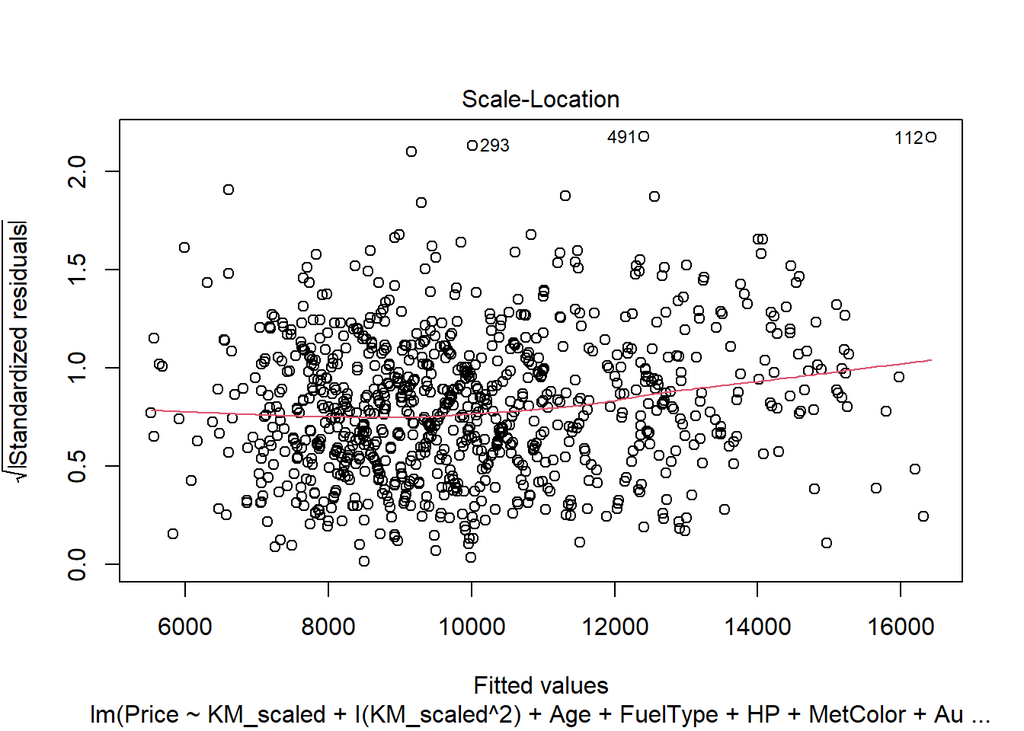

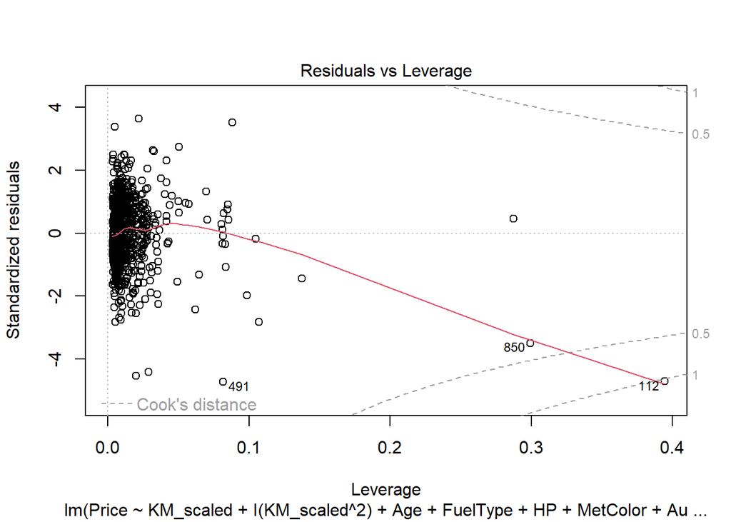

```r
#1- Heteroscedasticity -> we have a little problem
#2- QQ-plot -> serious skewness to left
#3- like 1
#4- we have one observation in Cook's Distance zone (has huge effect on our model)
plot(m3)
```

## 6.6 Model 3_2:

Revise m3 model with significant variables to predict ‘Price’:

```r
m3_2 <- lm(Price ~ KM_scaled + I(KM_scaled^2) + Age + FuelType + Automatic + CC + Weight + Doors, data = train)
summary(m3_2)
```

```
##
## Call:
## lm(formula = Price ~ KM_scaled + I(KM_scaled^2) + Age + FuelType +
##     Automatic + CC + Weight + Doors, data = train)
##
## Residuals:
##     Min      1Q  Median      3Q     Max
## -5098.7  -655.9    -3.2   685.4  3935.5
##
## Coefficients:
##                  Estimate Std. Error t value Pr(>|t|)
## (Intercept)     6593.2421  1250.9450   5.271 1.70e-07 ***
## KM_scaled       -418.4221    53.2850  -7.853 1.14e-14 ***
## I(KM_scaled^2)   -45.1643    22.8966  -1.973  0.04885 *
## Age             -113.8360     2.8661 -39.719  < 2e-16 ***
## FuelTypeDiesel -1113.4155   204.3215  -5.449 6.50e-08 ***
## FuelTypeCNG     -594.4781   312.8398  -1.900  0.05771 .
## Automatic1       466.6157   160.6478   2.905  0.00377 **
## CC                 1.1061     0.3274   3.378  0.00076 ***
## Weight             7.8852     1.2525   6.296 4.75e-10 ***
## Doors5           198.7748    80.6100   2.466  0.01385 *
## Doors4           115.0239   129.9884   0.885  0.37645
## Doors2          -302.5883  1083.4502  -0.279  0.78009
## ---
## Signif. codes:  0 '***' 0.001 '**' 0.01 '*' 0.05 '.' 0.1 ' ' 1
##
## Residual standard error: 1080 on 915 degrees of freedom
## Multiple R-squared:  0.7901, Adjusted R-squared:  0.7876
## F-statistic: 313.1 on 11 and 915 DF,  p-value: < 2.2e-16
```

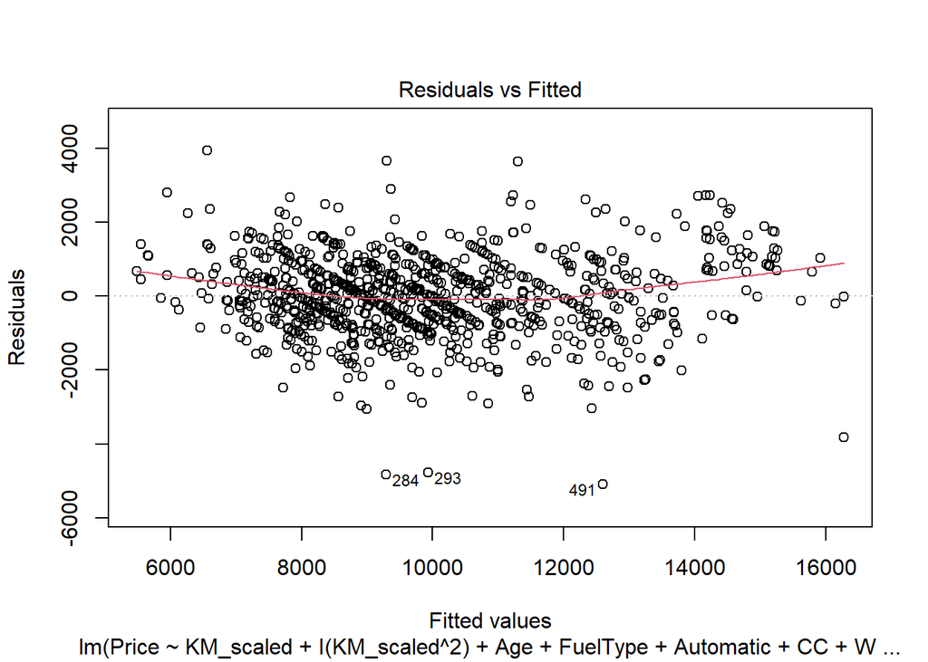

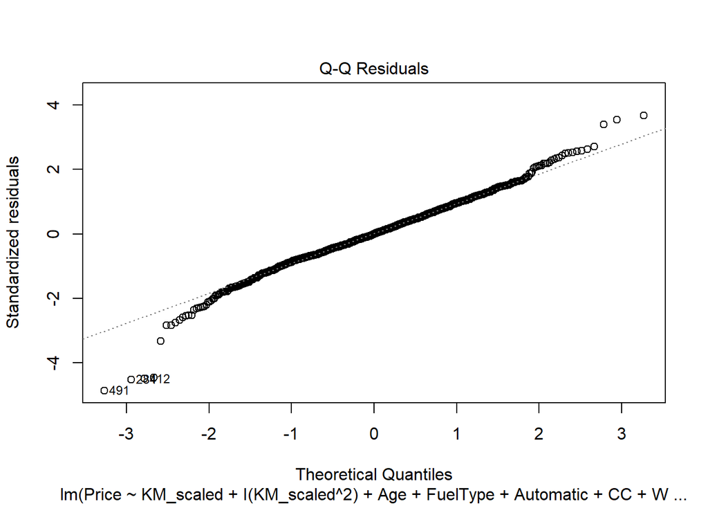

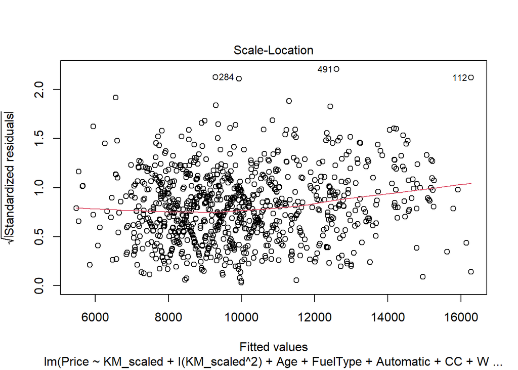

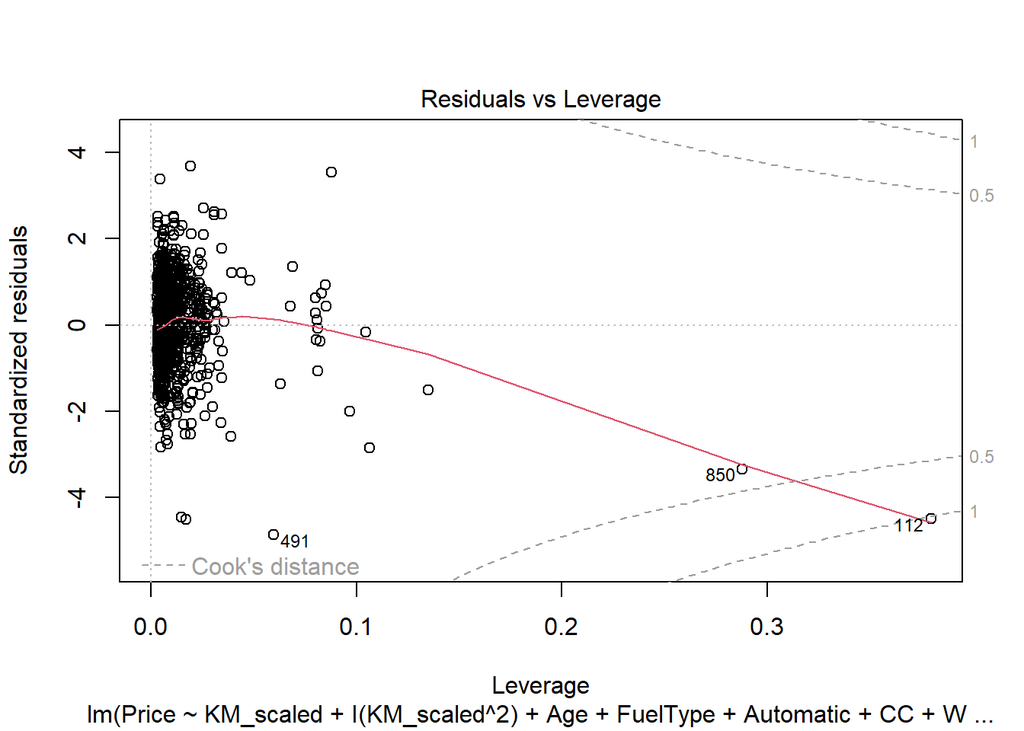

```r
plot(m3_2)
```

```r
car::vif(m3_2)
```

```
##                    GVIF Df GVIF^(1/(2*Df))
## KM_scaled      2.252788  1        1.500929
## I(KM_scaled^2) 1.668981  1        1.291890
## Age            1.500500  1        1.224949
## FuelType       3.141513  2        1.331327
## Automatic      1.065719  1        1.032337
## CC             2.981711  1        1.726763
## Weight         2.330551  1        1.526614
## Doors          1.283089  3        1.042420
```

## 6.7 Model 4

Create another variable:

```r
train$IfPetrol <- ifelse(train$FuelType == 'Petrol', T, F)  # put the Petrol as the base category
head(train)
```

|  | Price | Age | KM | FuelType | HP | MetColor | Automatic | CC | Doors | Weight | KM_scaled | IfPetrol |
| --- | --- | --- | --- | --- | --- | --- | --- | --- | --- | --- | --- | --- |
| 1084 | 7500 | 78 | 89953 | Petrol | 110 | 0 | 0 | 1600 | 5 | 1114 | 0.47016154 | TRUE |
| 234 | 11950 | 41 | 29056 | Petrol | 97 | 1 | 0 | 1400 | 5 | 1060 | -1.22212888 | TRUE |
| 1066 | 9250 | 80 | 93841 | Petrol | 110 | 0 | 0 | 1600 | 5 | 1070 | 0.57820668 | TRUE |
| 1150 | 7950 | 72 | 75840 | Petrol | 86 | 0 | 0 | 1300 | 5 | 1035 | 0.07796989 | TRUE |
| 711 | 8450 | 64 | 70116 | Petrol | 110 | 1 | 0 | 1600 | 4 | 1035 | -0.08109657 | TRUE |
| 237 | 13450 | 40 | 28362 | Petrol | 110 | 1 | 0 | 1600 | 3 | 1040 | -1.24141472 | TRUE |

```r
summary(train$IfPetrol)  # solve CNG small sample size problem and make balance between categories (Capping)
```

```
##    Mode   FALSE    TRUE
## logical     107     820
```

```r
m4 <- lm(Price ~ KM_scaled + I(KM_scaled^2) + Age + IfPetrol + Automatic + CC + Weight, data = train)

summary(m4)
```

```
##
## Call:
## lm(formula = Price ~ KM_scaled + I(KM_scaled^2) + Age + IfPetrol +
##     Automatic + CC + Weight, data = train)
##
## Residuals:
##     Min      1Q  Median      3Q     Max
## -5358.3  -655.1     8.9   682.7  4127.9
##
## Coefficients:
##                 Estimate Std. Error t value Pr(>|t|)
## (Intercept)    4862.1130  1229.8373   3.953 8.29e-05 ***
## KM_scaled      -415.3330    53.3674  -7.783 1.91e-14 ***
## I(KM_scaled^2)  -48.8231    22.8112  -2.140  0.03259 *
## Age            -113.9792     2.8716 -39.691  < 2e-16 ***
## IfPetrolTRUE   1062.5472   181.2779   5.861 6.39e-09 ***
## Automatic1      452.4074   160.2564   2.823  0.00486 **
## CC                0.9939     0.3069   3.238  0.00125 **
## Weight            8.7822     1.1503   7.635 5.67e-14 ***
## ---
## Signif. codes:  0 '***' 0.001 '**' 0.01 '*' 0.05 '.' 0.1 ' ' 1
##
## Residual standard error: 1083 on 919 degrees of freedom
## Multiple R-squared:  0.788,  Adjusted R-squared:  0.7864
## F-statistic:   488 on 7 and 919 DF,  p-value: < 2.2e-16
```

> **Adjusted R<sup>2</sup>** did not change -> confirm that the removed variables were not important variables for explanation of Price

> **F-test**: p-value < 0.05 -> there is at least one linear relationship between one of the predictor variables and Price

Check Assumptions of Regression

1. Normality of residuals

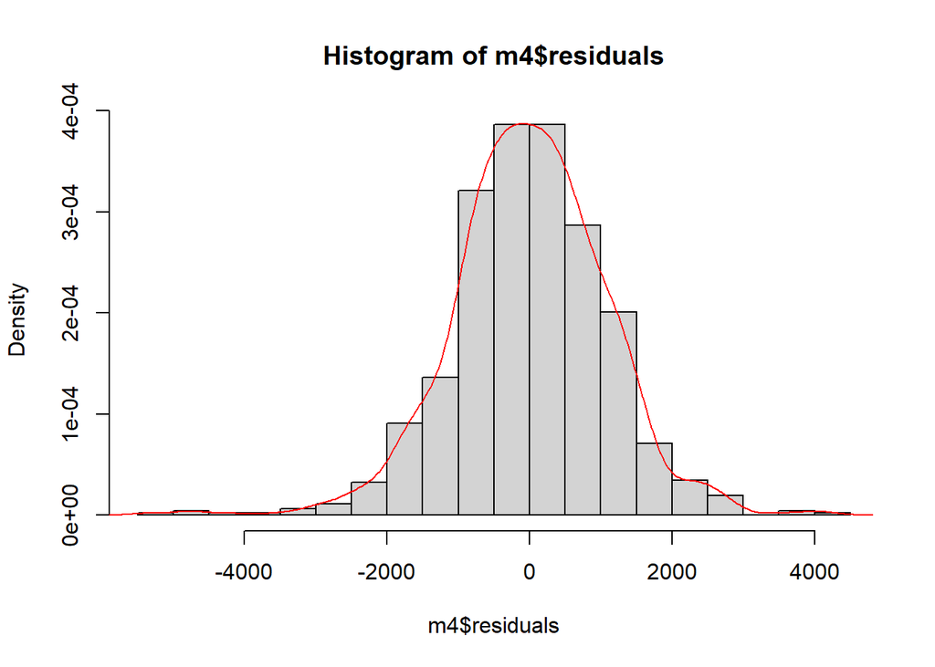

```r
hist(m4$residuals, freq = F, breaks = 25)
lines(density(m4$residuals), col='red')  # a little skewed to left
```

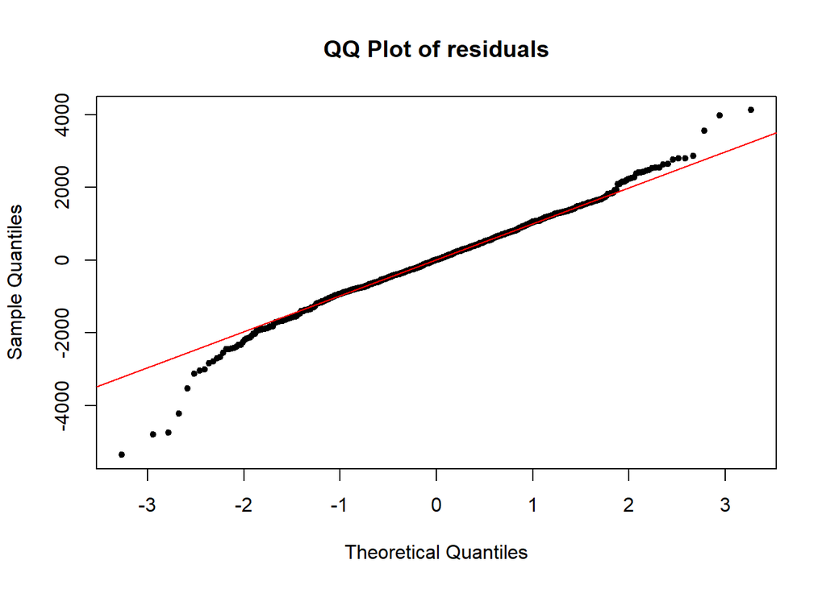

```r
qqnorm(m4$residuals, main='QQ Plot of residuals', pch = 20)
qqline(m4$residuals, col = 'red')
```

```r
#p-value < 0.05 reject normality assumption
jarque.test(m4$residuals)
```

```
##
##  Jarque-Bera Normality Test
##
## data:  m4$residuals
## JB = 134.52, p-value < 2.2e-16
## alternative hypothesis: greater
```

```r
#p-value < 0.05 reject normality assumption
anscombe.test(m4$residuals)
```

```
##
##  Anscombe-Glynn kurtosis test
##
## data:  m4$residuals
## kurt = 4.7864, z = 6.3867, p-value = 1.695e-10
## alternative hypothesis: kurtosis is not equal to 3
```

> **result**: Residuals are not Normally Distributed! (normality assumption did not confirm)

Diagnostic Plots

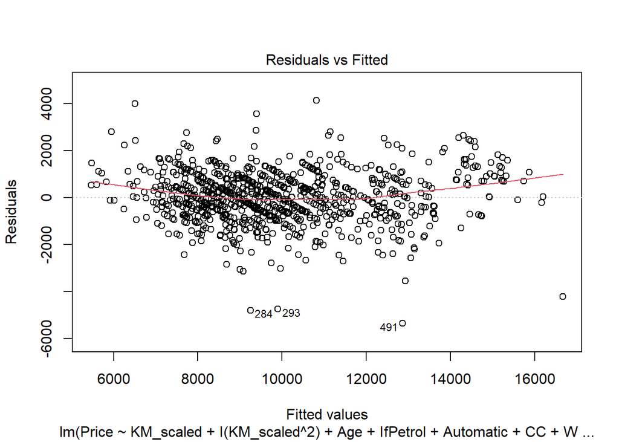

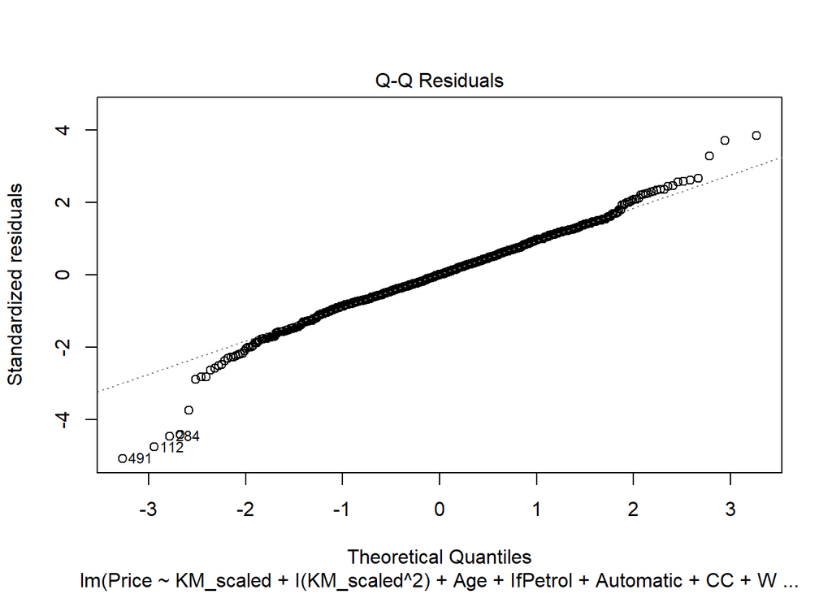

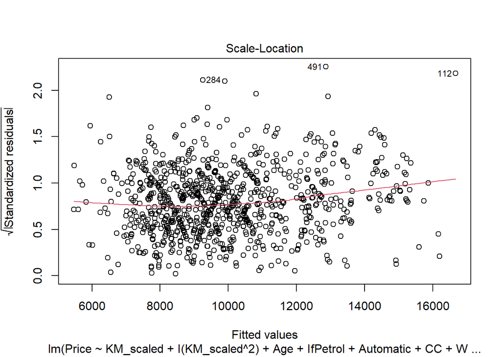

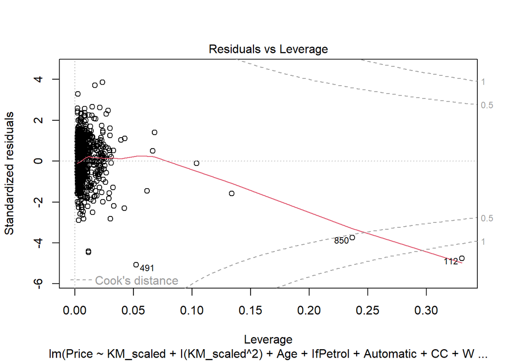

```r
#1- Hetersocedasticity: a little
#2- QQ-plot
#3- like 1
#4- two outliers based-on Cook's Distance (if we remove them, will have important change on Regression line)
plot(m4)
```

> **Model 4_2**: remove some outlier observations to improve model (to close model errors distribution to Normal)

Maybe just some outlier observations are cause of Errors Normality Assumption violation.

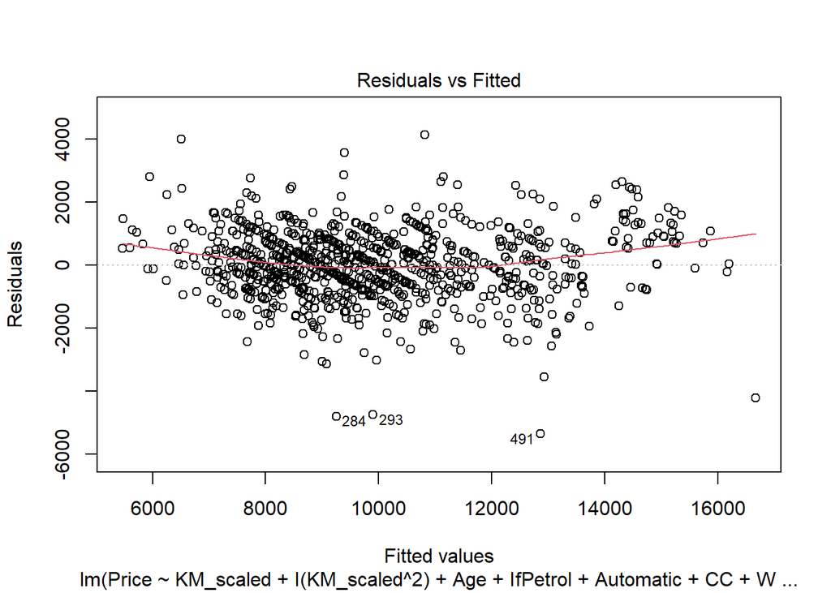

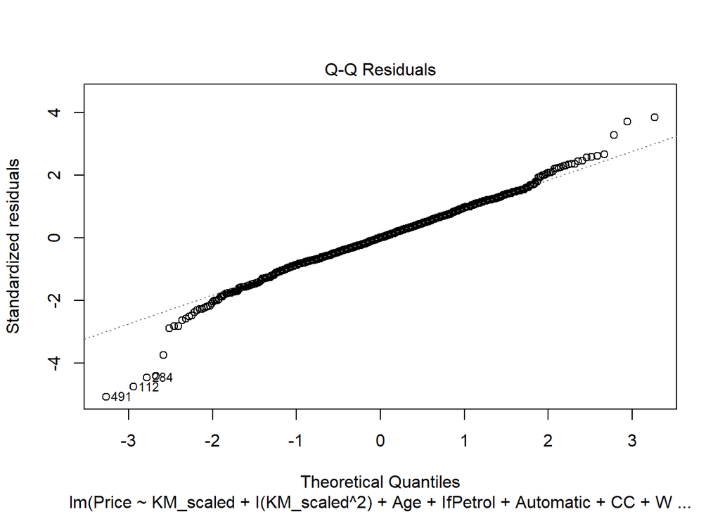

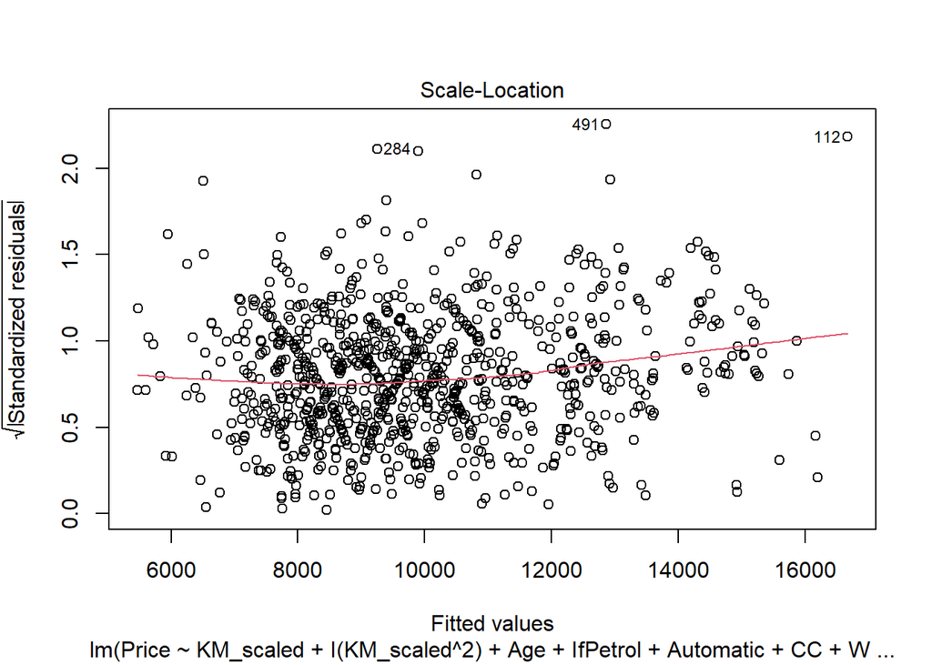

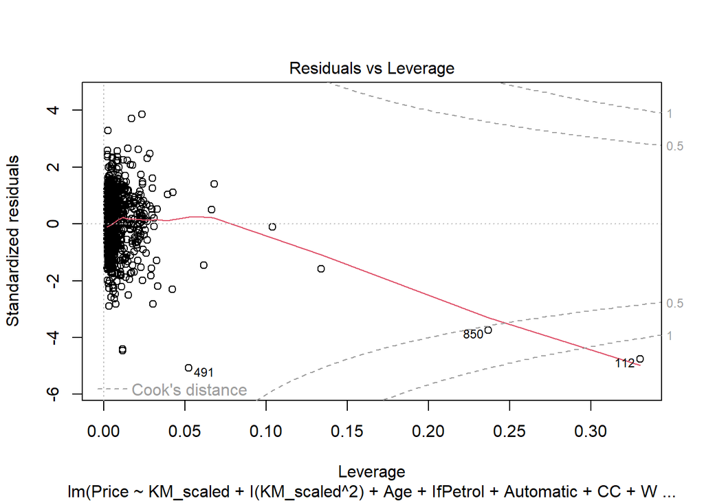

```r
plot(m4)
```

```r
train2 <- train[-which(rownames(train) %in% c(112, 284, 293, 491, 850)), ]  # iteration 1) remove some outliers based-on Diagnostic Plots

m4_2 <- lm(Price ~ KM_scaled + I(KM_scaled^2) + Age + IfPetrol + Automatic + CC + Weight, data = train2)
summary(m4_2)
```

```
##
## Call:
## lm(formula = Price ~ KM_scaled + I(KM_scaled^2) + Age + IfPetrol +
##     Automatic + CC + Weight, data = train2)
##
## Residuals:
##     Min      1Q  Median      3Q     Max
## -4706.7  -636.8   -11.1   639.9  4312.2
##
## Coefficients:
##                  Estimate Std. Error t value Pr(>|t|)
## (Intercept)    -6167.8009  1623.1642  -3.800 0.000154 ***
## KM_scaled       -453.3795    50.1087  -9.048  < 2e-16 ***
## I(KM_scaled^2)   -48.8085    21.2111  -2.301 0.021611 *
## Age             -105.0178     2.8045 -37.447  < 2e-16 ***
## IfPetrolTRUE    1138.2472   171.2443   6.647 5.14e-11 ***
## Automatic1       119.6244   151.9560   0.787 0.431351
## CC                -0.4308     0.3212  -1.341 0.180211
## Weight            20.7123     1.6327  12.686  < 2e-16 ***
## ---
## Signif. codes:  0 '***' 0.001 '**' 0.01 '*' 0.05 '.' 0.1 ' ' 1
##
## Residual standard error: 1002 on 914 degrees of freedom
## Multiple R-squared:  0.8173, Adjusted R-squared:  0.8159
## F-statistic: 584.2 on 7 and 914 DF,  p-value: < 2.2e-16
```

- **R<sup>2</sup>** improved
- **KM<sup>2</sup>** marginal significant
- **Automatic1** is not significant
- **CC** is not significant

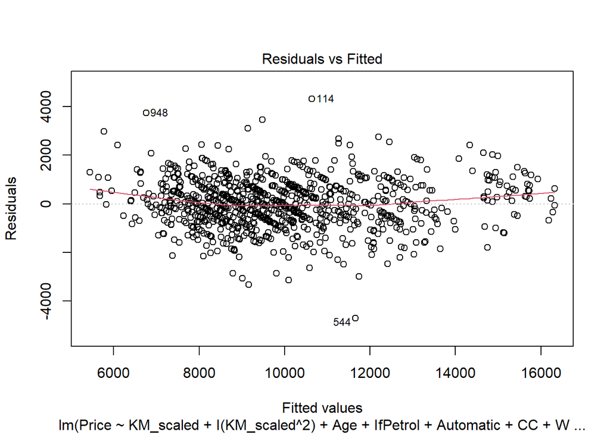

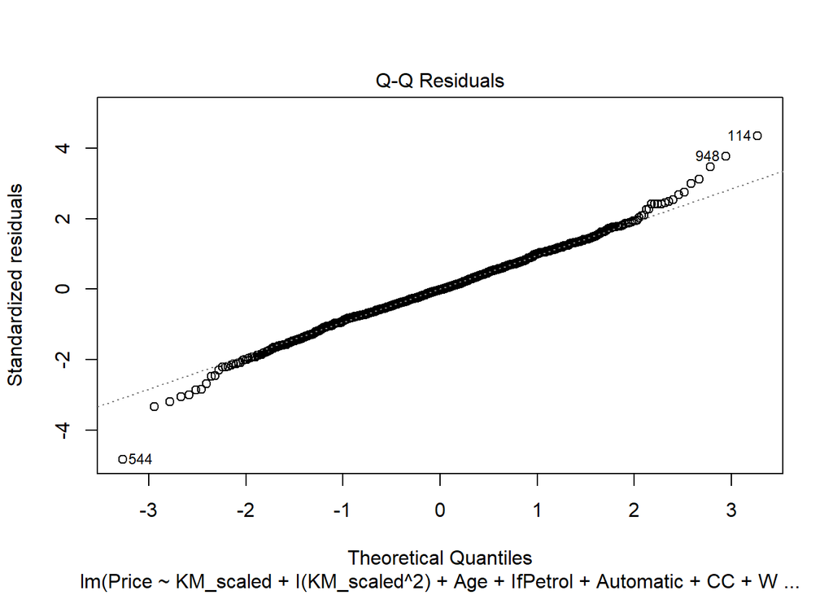

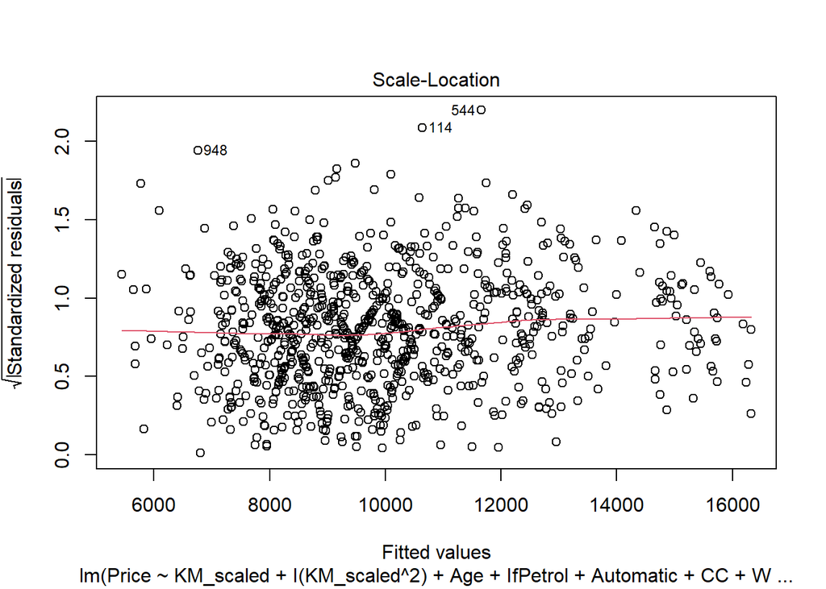

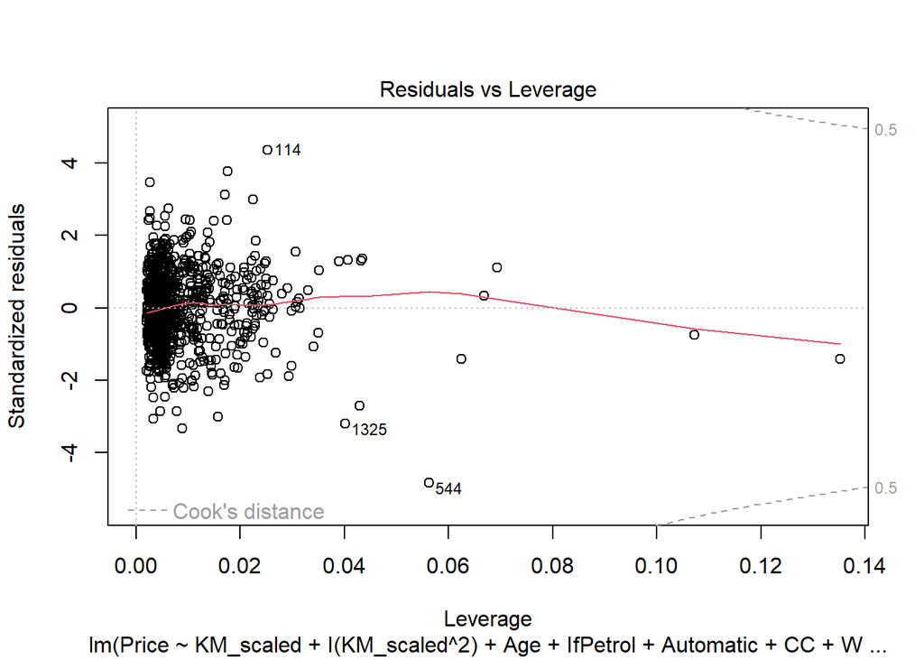

```r
plot(m4_2)
```